# Calibration knowledge

[Matt Jaquiery](https://github.com/mjaquiery) (matt.jaquiery@psy.ox.ac.uk)

December 2019

[Script run 2020-04-16 12:31:38]

# Introduction

We hypothesised that participants would show greater sensitivity to the confidence of advice when they knew the identify of the advisor.

- Version 0.1.3
  - The previous version showed participants lacked sensitivity to the difference in advisor confidence (they failed to correct for over/underconfidence in the advice). Here we separate advice more dramatically and clearly in an attempt to establish rough equivalence between the advisors when participants are aware of the advisor’s properties. We also added scorecards to give participants a clear visual indication of how the advisors perform compared to one another.

# Method

The experimental code is available on [GitHub](https://github.com/oxacclab/ExploringSocialMetacognition), and the experiment can be performed by visiting [https://acclab.psy.ox.ac.uk/~mj221/ESM/ACBin/ce.html](https://acclab.psy.ox.ac.uk/~mj221/ESM/ACBin/ck.html?PROLIFIC_PID=WriteUp).

# Results

## Exclusions

```
##
##                  highFirst lowFirst
##   FALSE                 17       18
##   keyTrialCount          3        4
##   outlyingTrials         3        3
```

Our final participant list consists of 35 participants who completed an average of 45.91 trials each, of which an average of 27.94 had no feedback.

## Task performance

First we offer a characterisation of the task, to provide the reader with a sense of how the participants performed.

### Decisions

Participants offered estimates of whether various events took place before or after a given year. The correct answers were always between 1900 and 2000. Participants answered by selecting a point on one of two confidence bars, with the choice of bar indicating the chosen answer.

#### Correctness

| decision | mean | CL95.Low | CL95.High | Phase |
| --- | --- | --- | --- | --- |
| first | .654 | .599 | .709 | Familiarization |
| last | .738 | .698 | .777 | Familiarization |
| Overall | .696 | .651 | .740 | Familiarization |

| decision | mean | CL95.Low | CL95.High | Phase |
| --- | --- | --- | --- | --- |
| first | .588 | .546 | .630 | Test |
| last | .642 | .603 | .681 | Test |
| Overall | .615 | .578 | .652 | Test |

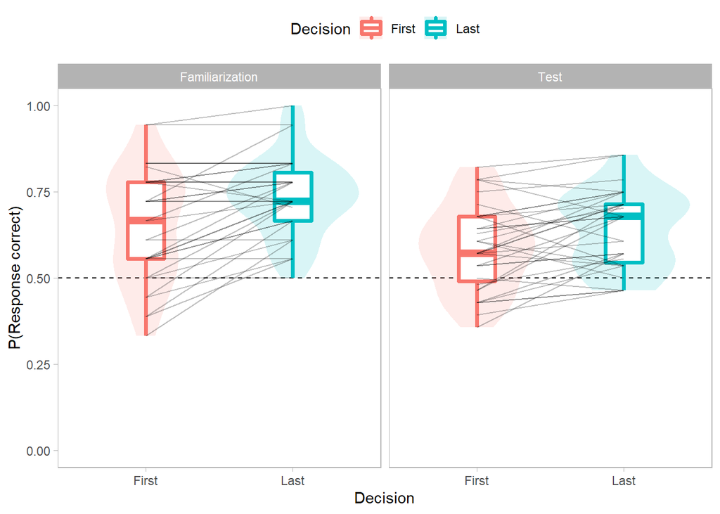

### Timing

We can look at the response time - the difference between the time the response is opened and the time the response is received.

| decision | mean | CL95.Low | CL95.High | Phase |
| --- | --- | --- | --- | --- |
| first | 5866.713 | 5093.664 | 6639.763 | Familiarization |
| last | 1513.120 | 1226.821 | 1799.420 | Familiarization |
| Overall | 3689.917 | 3200.061 | 4179.773 | Familiarization |

| decision | mean | CL95.Low | CL95.High | Phase |
| --- | --- | --- | --- | --- |
| first | 5758.979 | 4989.655 | 6528.304 | Test |
| last | 1575.272 | 1324.908 | 1825.637 | Test |
| Overall | 3667.126 | 3206.205 | 4128.047 | Test |

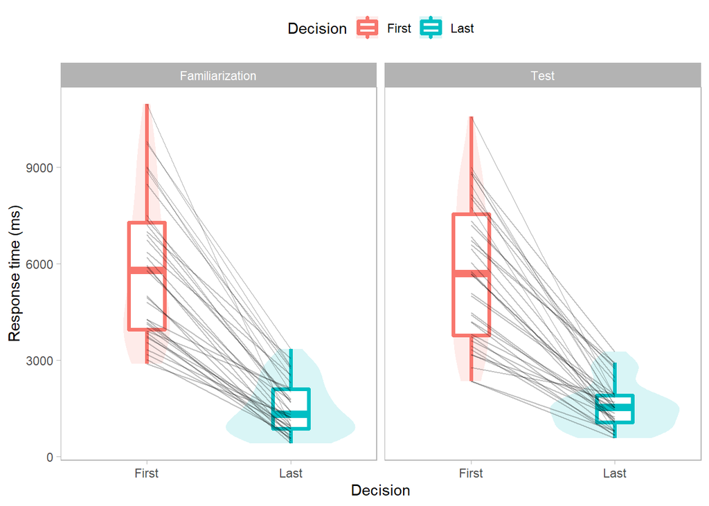

### Summary

Participants initial estimates were clearly better than chance in both the familiarization and test phases. Final decisions, made after seeing advice, were better still. These results indicate that participants found the task possible, and found the advice helpful. Participants made final decisions much more quickly than initial estimates, although they were likely processing advice information during the 2s window in which advice is animated on the screen.

## Metacognitive performance

### Confidence

Each answer bar allowed the participant to express their confidence in that answer by selecting a higher point on the bar for a higher confidence, in a range of 0-100% for each decision.

| decision | mean | CL95.Low | CL95.High | Phase |
| --- | --- | --- | --- | --- |
| first | 54.477 | 47.065 | 61.890 | Test |
| last | 57.173 | 50.597 | 63.749 | Test |
| Overall | 55.825 | 48.946 | 62.704 | Test |

| decision | mean | CL95.Low | CL95.High | Phase |
| --- | --- | --- | --- | --- |
| first | 59.294 | 52.415 | 66.173 | Familiarization |
| last | 62.287 | 55.752 | 68.821 | Familiarization |
| Overall | 60.790 | 54.200 | 67.381 | Familiarization |

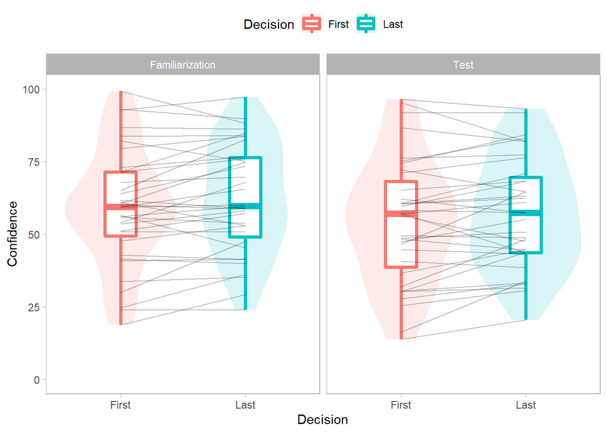

### Relationship between confidence and p(correct)

Participants indicated the confidence in their decisions simultaneously with the decisions themselves. We can thus explore how well a participant’s confidence signals their accuracy. We provide only a brief examination here where normalised responses are split into high and low confidence for each participant (by the participant’s mean confidence), and the accuracies of the two categories are compared. This is done separately for first and last decisions.

| decision | mean | CL95.Low | CL95.High |
| --- | --- | --- | --- |
| first | .061 | -.001 | .123 |
| last | .186 | .139 | .233 |
| Overall | .123 | .077 | .170 |

```
## [1] "p(correct|high confidence) - p(correct|low confidence) for initial estimates"
```

```
## Bayes factor analysis
## --------------
## [1] Alt., r=0.707 : 1.070587 ±0%
##
## Against denominator:
##   Null, mu = 0
## ---
## Bayes factor type: BFoneSample, JZS
```

```
## [1] "p(correct|high confidence) - p(correct|low confidence) for final decisions"
```

```
## Bayes factor analysis
## --------------
## [1] Alt., r=0.707 : 5490513 ±0%
##
## Against denominator:
##   Null, mu = 0
## ---
## Bayes factor type: BFoneSample, JZS
```

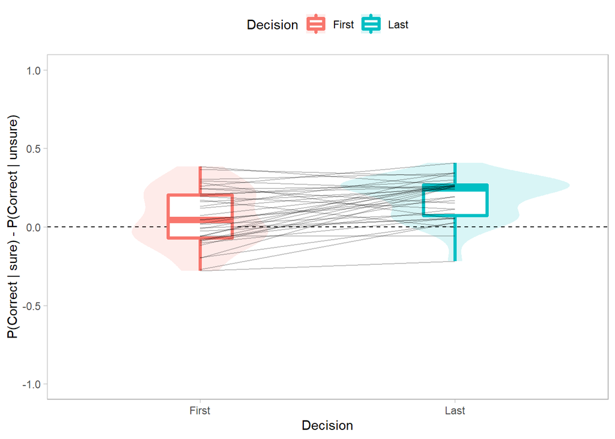

### Variance of confidence

Final decisions are more likely to be correct than initial estimates. This is not simply because participants are always unsure about the initial estimates because final decisions are no more confident on average. It is possible that participants use a medium confidence for all initial estimates which is then adjusted up or down for final decisions. If this is the case, the variance within a participant will be much lower for initial estimates than final decisions.

| Decision | confidenceSD | ciLow | ciHigh |
| --- | --- | --- | --- |
| First | 17.72176 | 17.33916 | 18.10437 |
| Last | 20.60613 | 20.32002 | 20.89225 |

### Summary

Participants’ answers were generally around the upper midpoint on the scale, with a fair amount of variation between participants. Confidence in final decisions did not appear to be consistently higher than initial estimates, although this is unsurprising given the final decisions are not split by whether the advisor agreed with the initial decision.

The relationship between confidence and the probability of being correct is essentially zero for initial estimates, indicating that participants’ initial estimates might feel like guesses (albeit good ones). Final decisions did show a relationship where higher confidence in decisions was indicative of a greater probability of being correct, presumably because participants’ confidence was readily affected by advice. This pattern was true for most participants individually, as well as for the sample as a whole.

Individuals’ confidence ratings for their initial estimates were less varied than their confidence ratings for their final decisions. This, combined with the other results, suggests that perhaps individuals were generally unsure about their initial estimates and became more or less sure as a function of the advice.

## Advisor performance - Familiarisation

Participants in should get an appropriate experience of each advisor in the Familiariasation phase, during which they get feedback after each question. This means that the accuracy and metacognitive sensitivity of the advisors should be balanced, while the confidence (metacognitive bias) is not.

*N.B.*: Advisors’ advice was closely choreographed during this study, so the graphs below show little variation in advice.

### Accuracy

| Advisor | Phase | advisorAccuracy | advisorAgree |
| --- | --- | --- | --- |
| HighConf | Familiarization | .667 | .562 |
| LowConf | Familiarization | .669 | .589 |

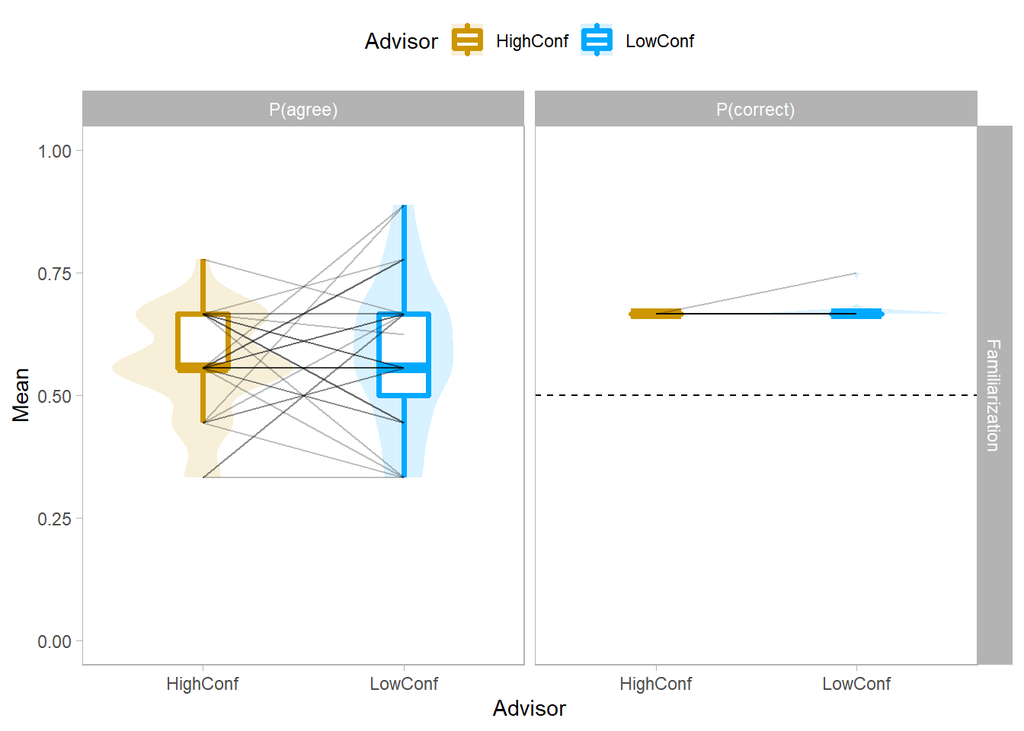

### Advisor confidence

The advisors differ by design in their confidence, so participants should experience these differences.

| Advisor | Phase | confidence |
| --- | --- | --- |
| HighConf | Familiarization | 67.4 |
| LowConf | Familiarization | 33.9 |

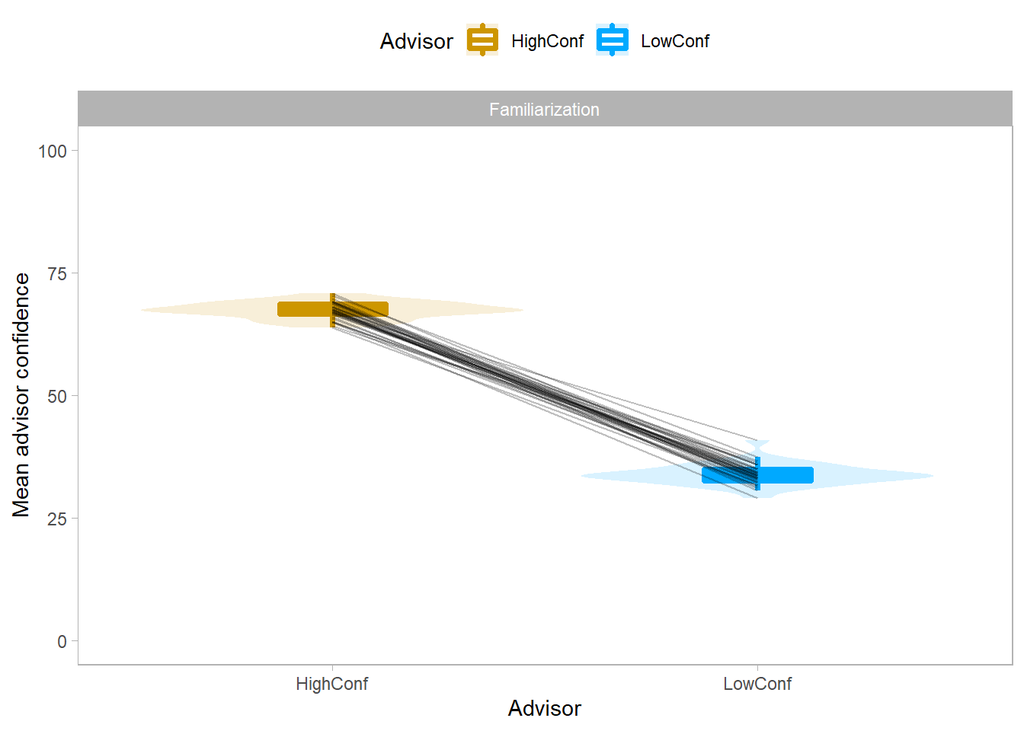

#### Planned advice distributions

The advisors’ advice distributions are arranged as shown below. The advisors have the same level of accuracy at high (100%), medium (66%), and low (33%) idiosyncratic confidence. They differ in how their idiosyncratic confidence maps to the confidence scale, with the low confidence advisor using the bottom and middle parts of the scale, while the high confidence advisor uses the middle and top parts of the scale.

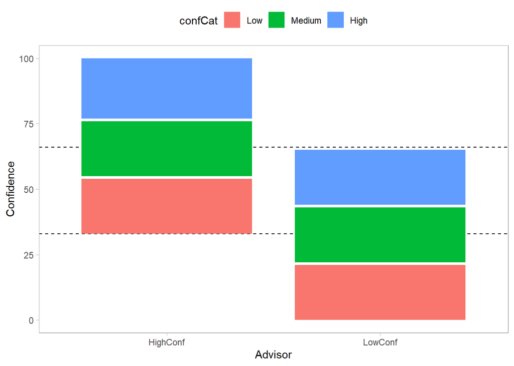

#### Individual participants’ experience

We should take a look at a handful of specific distributions experienced by individual participants to ensure the individual-level view tallies with the sample view.

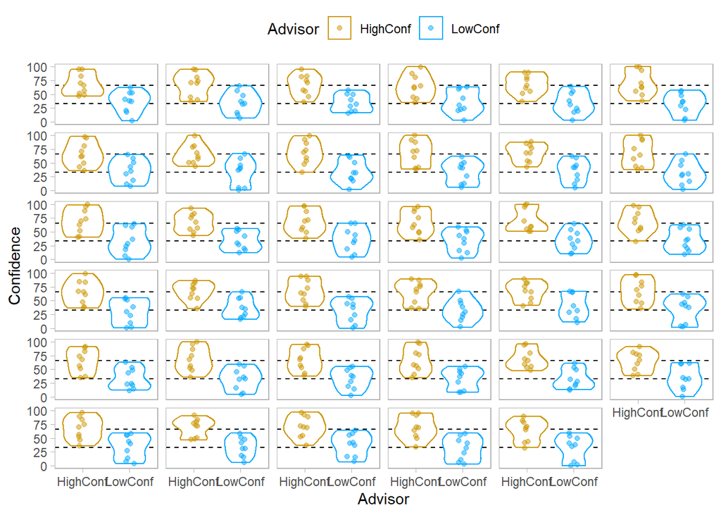

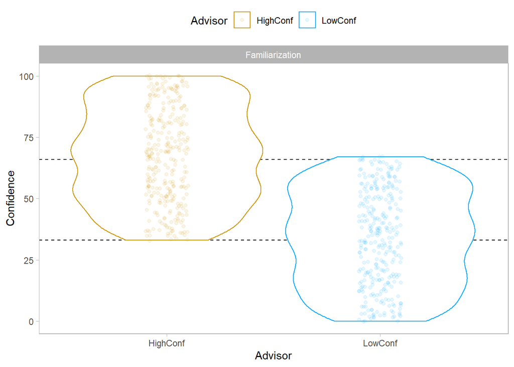

#### Summary

Participants’ individual experience was reflective of the aggregate experience, indicating that the scripted advice produced an experience which was similar for each participant.

### Distance

Distance is the continuous version of agreement - the difference along the confidence scale between the advice and the initial estimate. Where different scales are endorsed, the difference is the combination of how sure the participant was on one scale plus how sure the advisor was on the other.

| Advisor | Phase | adviceDistance |
| --- | --- | --- |
| HighConf | Familiarization | 67.1 |
| LowConf | Familiarization | 55.9 |

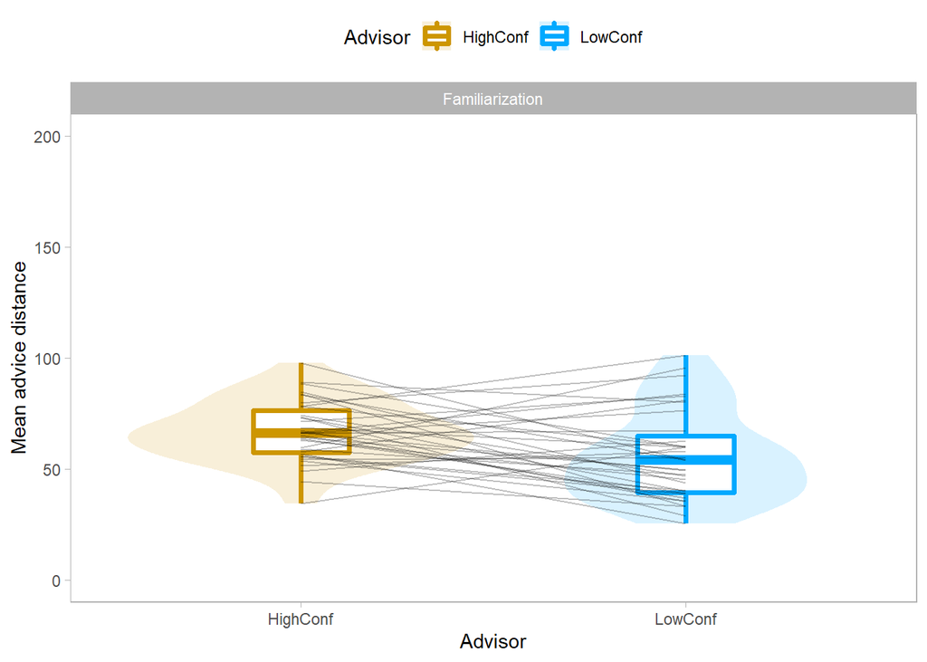

### Influence

The advisors should be roughly equally influential overall.

| advisor0idDescription | Agree | Phase | advisorInfluence |
| --- | --- | --- | --- |
| highConf | Agree | Familiarization | 4.0 |
| highConf | Disagree | Familiarization | 65.9 |
| lowConf | Agree | Familiarization | -5.7 |
| lowConf | Disagree | Familiarization | 34.3 |

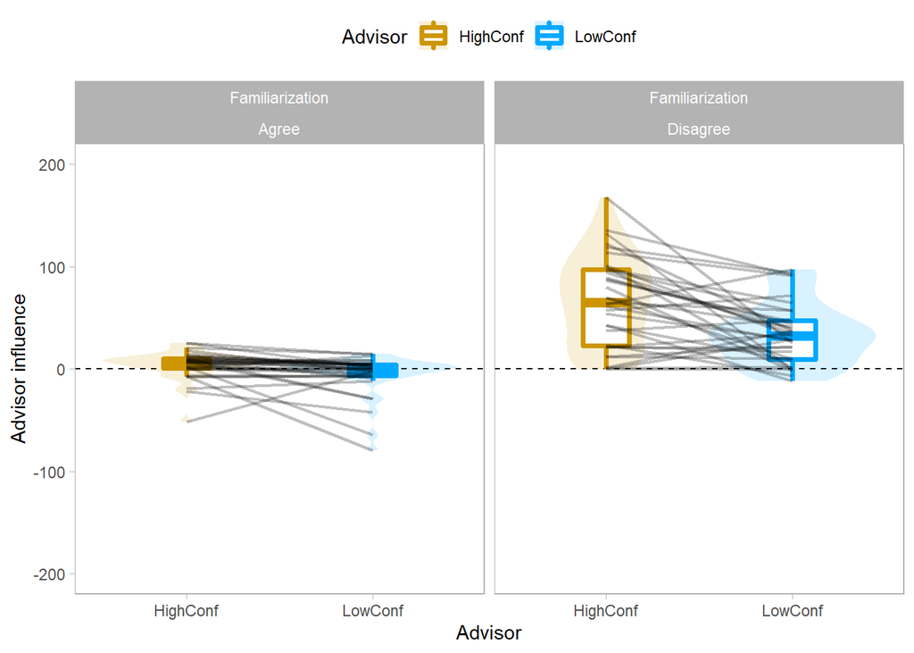

On the overlap trials, the low confidence advisor should be more influential than the high confidence advisor because this advisor is subjectively more confident and has a higher probability of being correct.

| advisor0idDescription | Agree | trials | advisorInfluence |
| --- | --- | --- | --- |
| highConf | Agree | Familiarization, Overlap | -7.5 |
| highConf | Disagree | Familiarization, Overlap | 47.7 |
| lowConf | Agree | Familiarization, Overlap | 3.7 |
| lowConf | Disagree | Familiarization, Overlap | 54.2 |

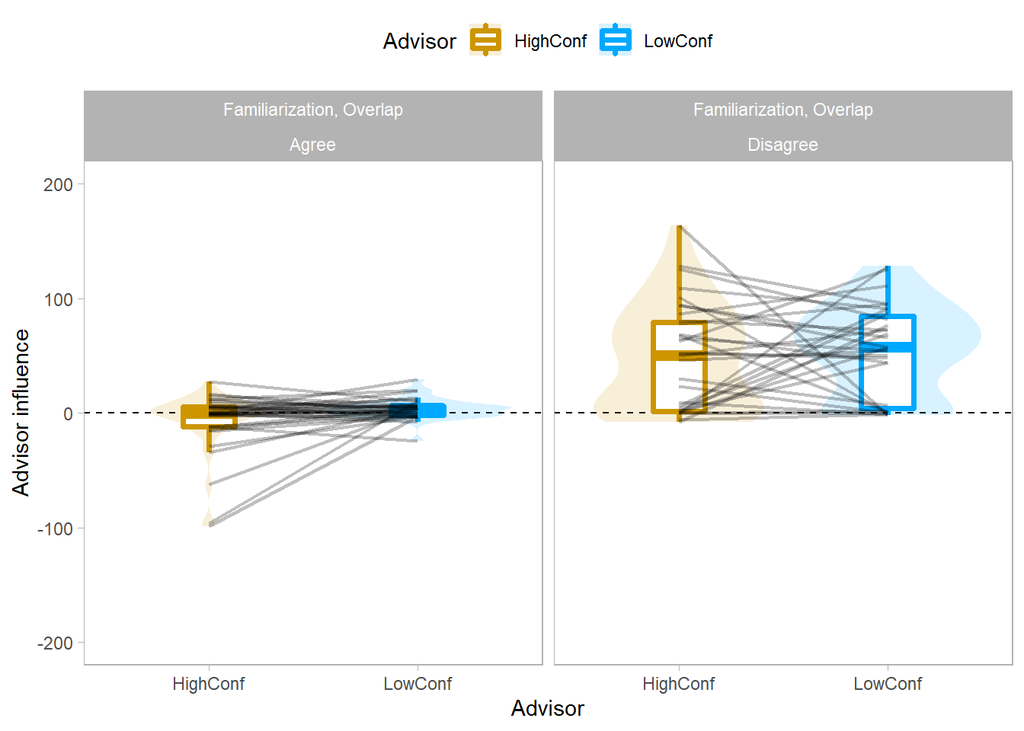

### Summary

The advisors’ performances were within the expected ranges for both the probability and extent of agreement with the participants and the objective accuracy of their advice. The advisors didn’t differ substantially from one another in any of these aspects.

To anticipate the main analysis, the influence of the advisors during the familiarity phase suggests that the high confidence advisor is more influential than the low confidence advisor (although both are far more influential in disagreement, as is to be expected from the asymmetric nature of the influence scale). When the advisors are compared on the overlap, the low confidence advisor is slightly more influential, but this effect should be much more pronounced: ideally the difference between the advisors here should favour the low confidence advisor to the same extent as comparing the least confident vs most confidence halves of an individual advisor’s advice.

It is possible that advice is being heavily taken, and that the high confidence advisor appears more influential because the advice is further away (meaning completely adopted advice shows as more influential for the high confidence advisor compared to the low confidence advisor). To investigate this possibility, an alternate measure of advice taking based on Weight on Advice can be calculated. This measure expresses the difference between the participant’s initial estimate and final decision as a proportion of the difference between the intial estimate and the initial estimate + advice, and quantifies advice taking as the relative weight of the former compared to the latter.

### Advice Weight

Advice weight expresses the distance between the initial estimate and final decision in terms of the initial estimate and advice (signed by agreement with the initial estimate). It can be thought of as stating the proportion of the advice used in the final decision. It is truncated at 1 and 0, and is undefined where the advice is the same as the initial estimate.

Intuitively, if the advisor indicates that they are 20 points sure in agreement with the participant, and the participant then increases their confidence by 20 points, the participant is considered to have taken 100% of the advice.

This measure controls for the distance between the initial estimate and the advice, while allowing advice to be expressed along a continuum rather than simply identifying a direction.

$$\omega' = \frac{
\text{initial} - f(\text{final}, \text{initial})
}{
\text{initial} - \text{min}(\text{initial} + f(\text{advice},\text{initial}), 100)
} \\
\omega = \text{clamp}_0^1(\omega')$$
Where $\text{min}(x,y)$ returns the lowest of its arguments, and

$$f(x,y) =
\begin{cases}
c_x, & s_x = s_y \\
-c_x, & s_x \neq s_y
\end{cases}$$
Where $c_x$ is the confidence of $x$, and $s_x$ is the side (before or after) chosen for $x$.

| advisor0idDescription | Agree | Phase | adviceWeight |
| --- | --- | --- | --- |
| highConf | Agree | Familiarization | 0.328 |
| highConf | Disagree | Familiarization | 0.592 |
| lowConf | Agree | Familiarization | 0.200 |
| lowConf | Disagree | Familiarization | 0.484 |

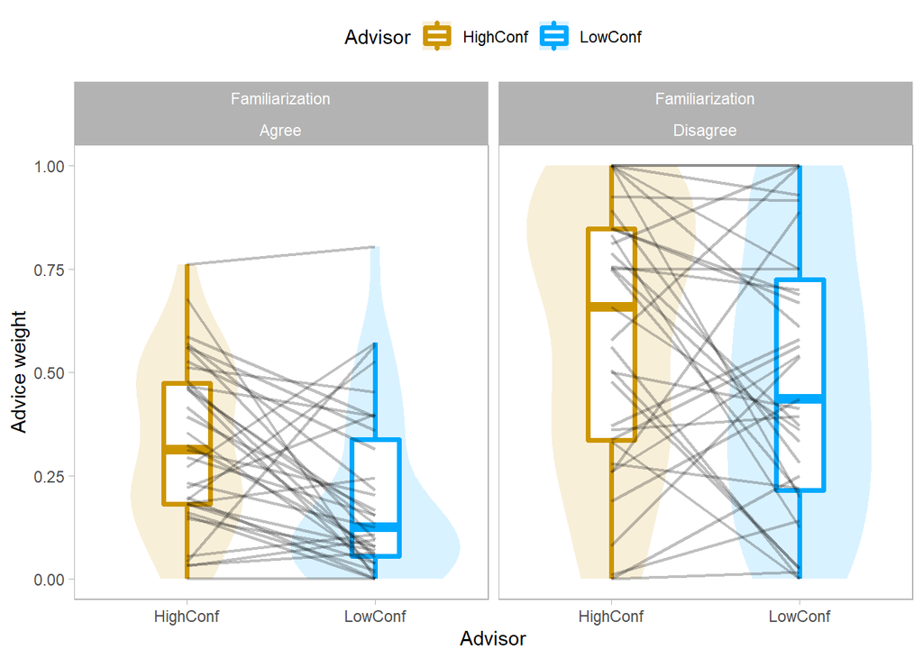

| advisor0idDescription | Agree | adviceWeight | trials |
| --- | --- | --- | --- |
| highConf | Agree | 0.154 | Familiarization, Overlap |
| highConf | Disagree | 0.508 | Familiarization, Overlap |
| lowConf | Agree | 0.203 | Familiarization, Overlap |
| lowConf | Disagree | 0.558 | Familiarization, Overlap |

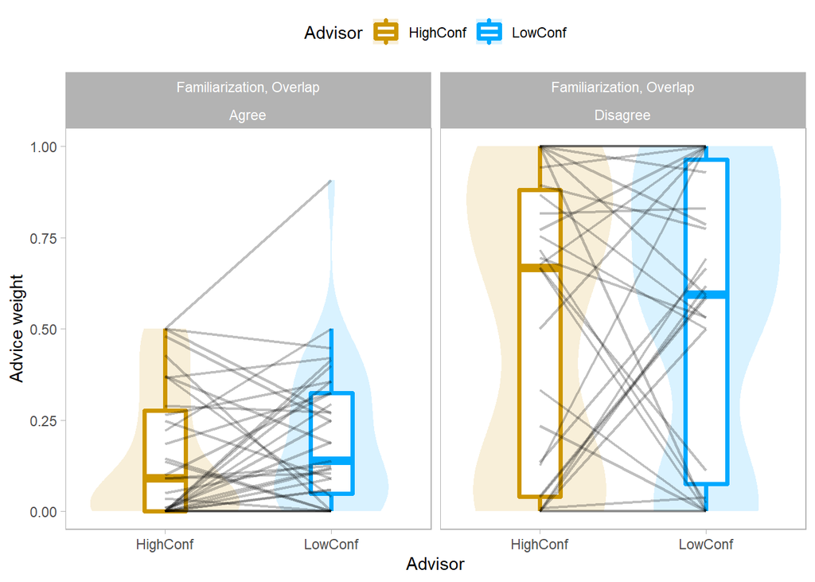

### Summary

The Advice Weight measure shows that advice is not being wholly adopted. Notably, disagreeing advice is more heavily adopted than agreeing advice, plausibly due to a tendency for some participants to reduce their confidence when agreed with (which can have the effect of bringing the final decision closer on the scale to the advice than the initial estimate), which is registered as 0.0 in the Advice Weight statistic.

The pattern is similar in both overlap and non-overlap trials, with a great deal more variation in Advice Weight under disagreement (expected from its higher mean), no clearly preferred advisor, and a roughly even split between Participants in which advisor has higher Advice Weight.

## Advisor performance - Test

### Key Trials

Trials in the Test block are split into Key and Foil trials. Key trials are matched across avisors such that each advisor-presentation-agreement combination has two trials per participant. There are three Foil trials per advisor-presentation combination per participant, and in these the low confidence advisor expresses low confidence while the high confidence advisor expresses high confidence.

The advisors are always correct on Foil trials, and their correctness on Key trials depends upon the participant: where they agree with a correct participant or disagree with an incorrect one they are correct, and where they agree with an incorrect participant or disagree with a correct one they are incorrect. Participants do not receive feedback on questions in the Test block.

All the analyses are conducted on Key trials only - information about Foil trials is only included to give a sense of how participants experienced the task.

#### Accuracy

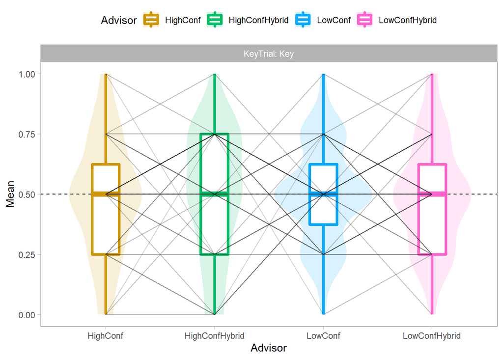

### Confidence

The advisors’ confidence is carefully controlled even during the Test phase. Foil trials are outside the overlap, while Key trials are within the overlap (and evenly spread between agreement and disagreement).

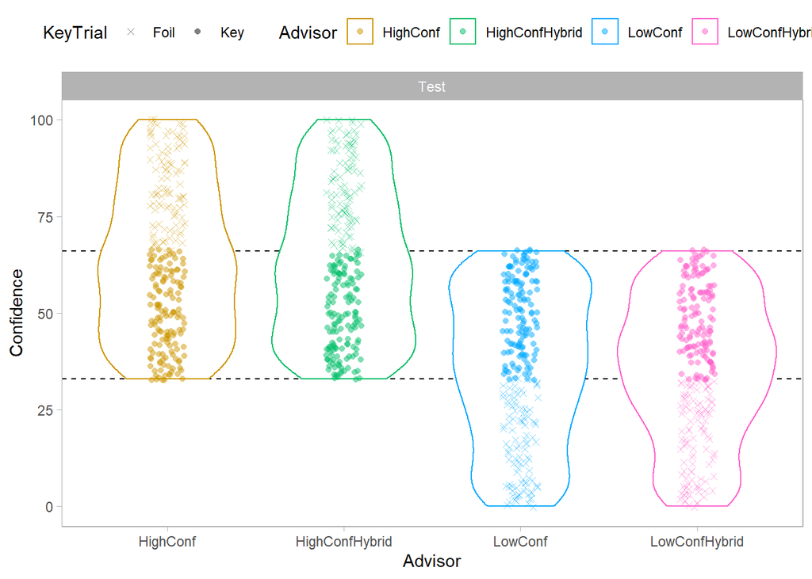

### Influence

The measure of influence is the extent to which a participant’s confidence moves in the expected direction as a function of the advice (increasing when agreed with, decreasing when disagreed with).

Influence is the primary outcome measure. Ideally it will be higher for the low confidence advisor because the Key trials occur in the overlap where the low confidence advisor is subjectively more confident.

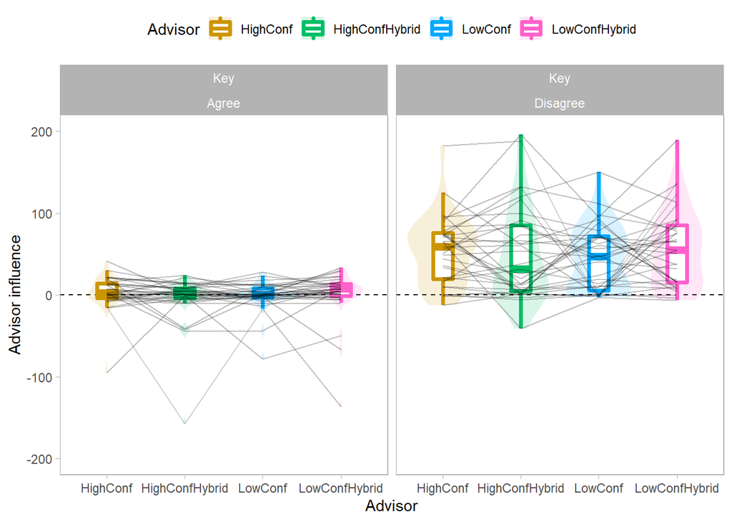

#### Most influential labelled advisor overall

```
## *t*(34) = 5.75, *p* < .001, *d* = 1.18, BF = 9834.55; *M*|HighConf = 35.73 [28.31, 43.14], *M*|LowConf = 12.53 [6.51, 18.54]
```

And for Key trials:

```
## *t*(34) = 1.66, *p*  = .106, *d* = 0.32, BF = 0.63; *M*|HighConf = 28.66 [20.81, 36.51], *M*|LowConf = 21.84 [15.15, 28.52]
```

#### Advice weight

For reasons discussed above, the Advice Weight statistic may be a better measure of how advice is used.

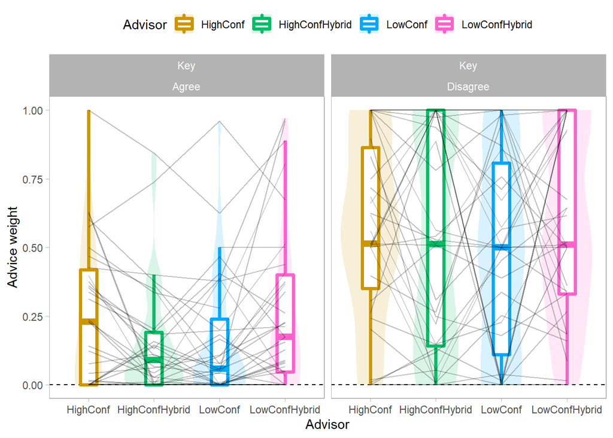

##### Most influential labelled advisor overall

```
## [1] "Dropping 1 participants with NA values."
```

```
## *t*(33) = 4.50, *p* < .001, *d* = 0.91, BF = 308.30; *M*|HighConf = 0.50 [0.42, 0.57], *M*|LowConf = 0.32 [0.25, 0.38]
```

And for Key trials:

```
## [1] "Dropping 1 participants with NA values."
```

```
## *t*(33) = 2.51, *p*  = .017, *d* = 0.45, BF = 2.72; *M*|HighConf = 0.42 [0.33, 0.50], *M*|LowConf = 0.32 [0.25, 0.39]
```

#### Influence scatter plots

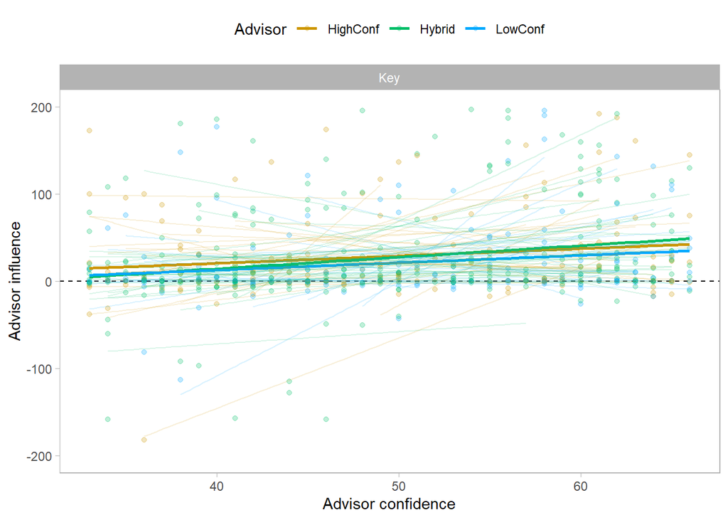

#### Influence distribution

It’s good to keep a general eye on the distribution of weight-on-advice on a trial-by-trial basis.

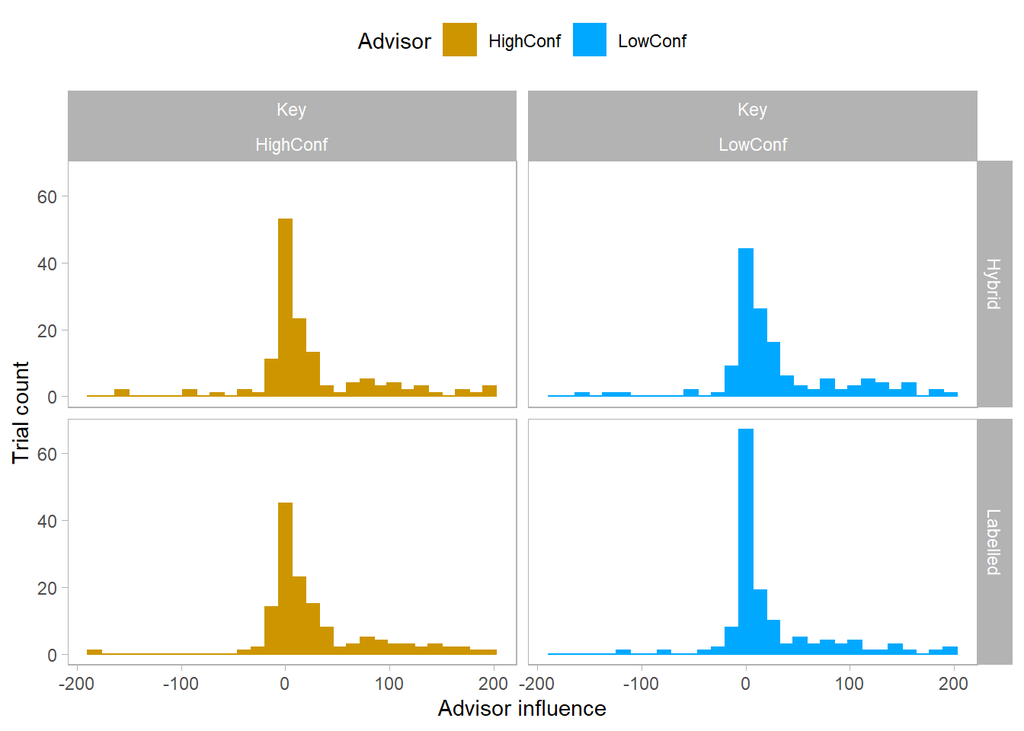

#### Is initial accuracy or initial confidence a better predictor of influence?

| property | BF | estimate | statistic | p.value | parameter | conf.low | conf.high |
| --- | --- | --- | --- | --- | --- | --- | --- |
| accuracy | 0.8957933 | -0.02801786 | -0.1032601 | 0.4800400 | 14 | -0.4887968 | 0.4466717 |
| confidence | 0.6503650 | -0.01812729 | -0.0619884 | 0.6585536 | 14 | -0.4970557 | 0.4706225 |

## Manipulation checks

Participants should learn the advisor mappings during the course of the experiment. This means that they should treat the low- and high-confidence advisors’ advice differently when those advisors express medium confidence on the scale. Specifically, they should be more highly influenced by the low-confidence advisor than by the high-confidence advisor.

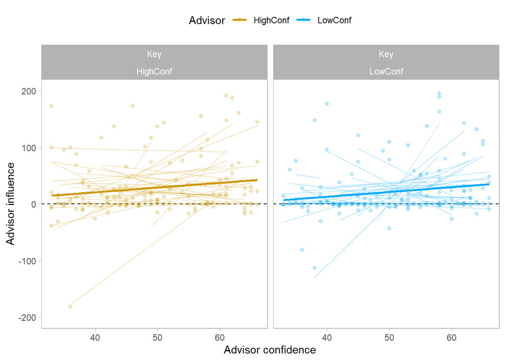

## Advisor preferences

In the hypothesis tests we need to know which advisor is most influential for each participant. We explore this influence on Familiarity trials.

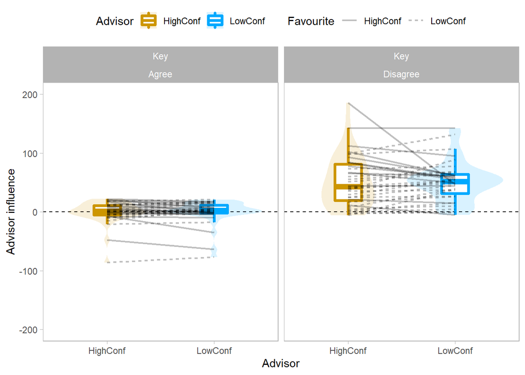

| favourite | n() |
| --- | --- |
| HighConf | 18 |
| LowConf | 17 |

### Advice weight

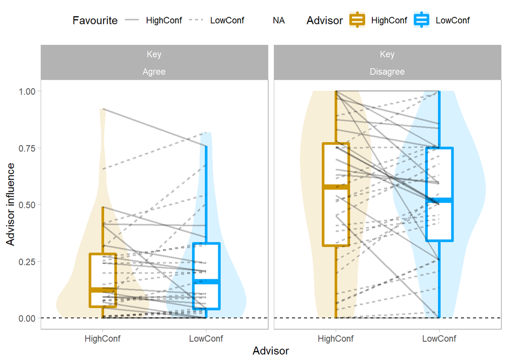

| favourite | n() |
| --- | --- |
| HighConf | 15 |
| LowConf | 16 |

### Summary

Participants are perhaps surprisingly fairly evenly spilt in terms of the advisor they find most influential. We might expect a high confidence advisor to be more influential than a low confidence one because people generally prefer high confidence, and because low confidence advice may tempt some people to reduce their confidence even if agreed with.

## Hypothesis testing

The hypotheses being tested here are:

1. Participants will place different weights on their least favourite advisor when they know that advisor’s identity compared to when that advisor is labelled as a hybrid (controlling for confidence).
   1. Advice influence

```
## *t*(34) = 0.04, *p*  = .965, *d* = 0.01, BF = 0.18; *M*|Labelled = 24.96 [18.41, 31.50], *M*|Hybrid = 24.68 [13.70, 35.66]
```

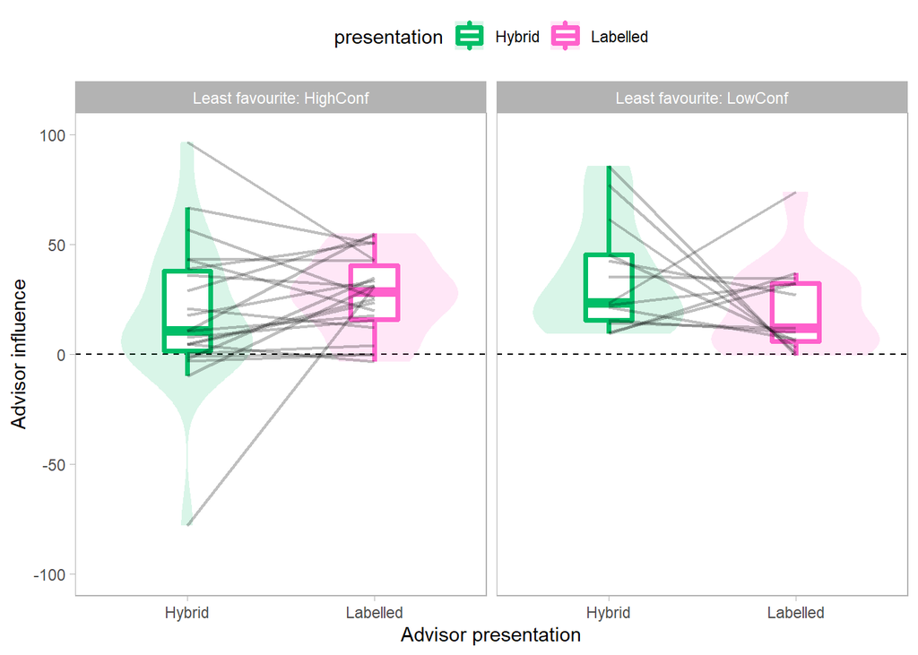

```
ii. Advice weight
```

[output not shown]

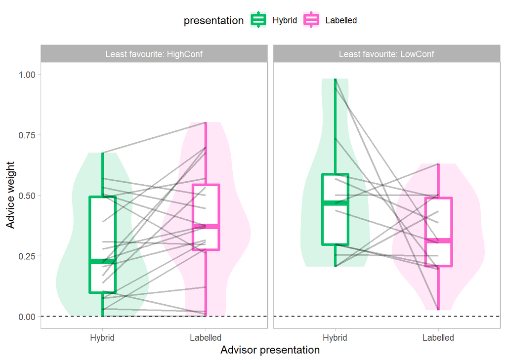

### Summary

There is some evidence to suggest that advice is treated similarly when it comes from the least favourite advisor regardless of whether that advice is labelled as belonging to the least favourite advisor or labelled with the hybrid avatar. This is an intuitively sensible strategy, though not in line with our hypothesis that people will have a superadditive dislike of source uncertainty.

# Exploration

## ANOVA

The experiment is structured suitably for a neat ANOVA comparing the effects of advisor and advisor labelling.

```
## $ANOVA
##                         Effect DFn DFd           F          p p<.05
## 2                       hybrid   1  34 0.051511465 0.82181292
## 3        advisor0idDescription   1  34 0.002095928 0.96375241
## 4 hybrid:advisor0idDescription   1  34 5.288113821 0.02773894     *
##            ges
## 2 4.135755e-04
## 3 5.107957e-06
## 4 1.625668e-02
```

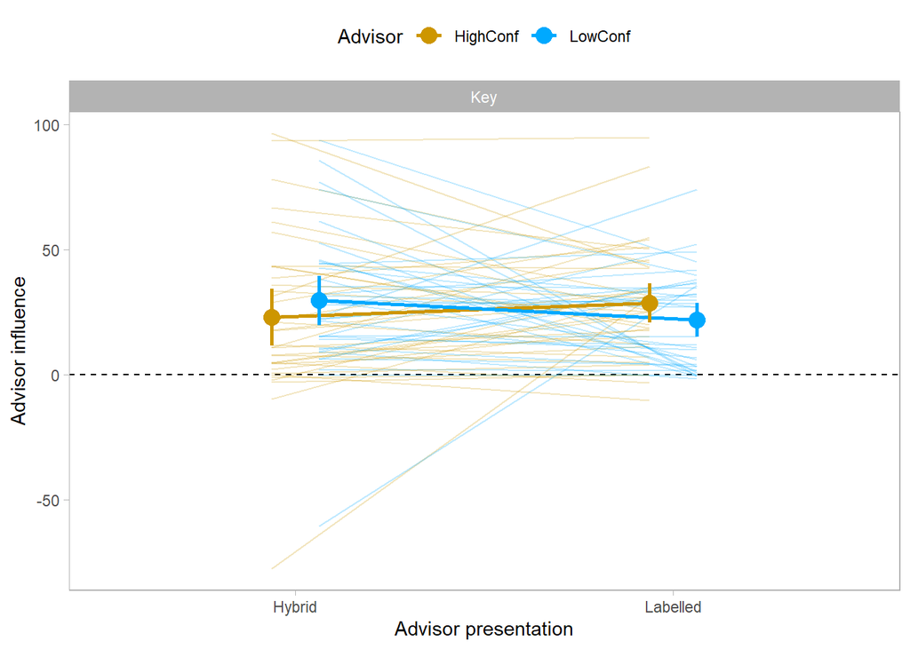

### Advice weight

```
## $ANOVA
##                         Effect DFn DFd         F           p p<.05
## 2                       hybrid   1  30 0.1378248 0.713062092
## 3        advisor0idDescription   1  30 0.1325141 0.718392610
## 4 hybrid:advisor0idDescription   1  30 9.1368447 0.005090112     *
##            ges
## 2 0.0010589178
## 3 0.0003967736
## 4 0.0436120347
```

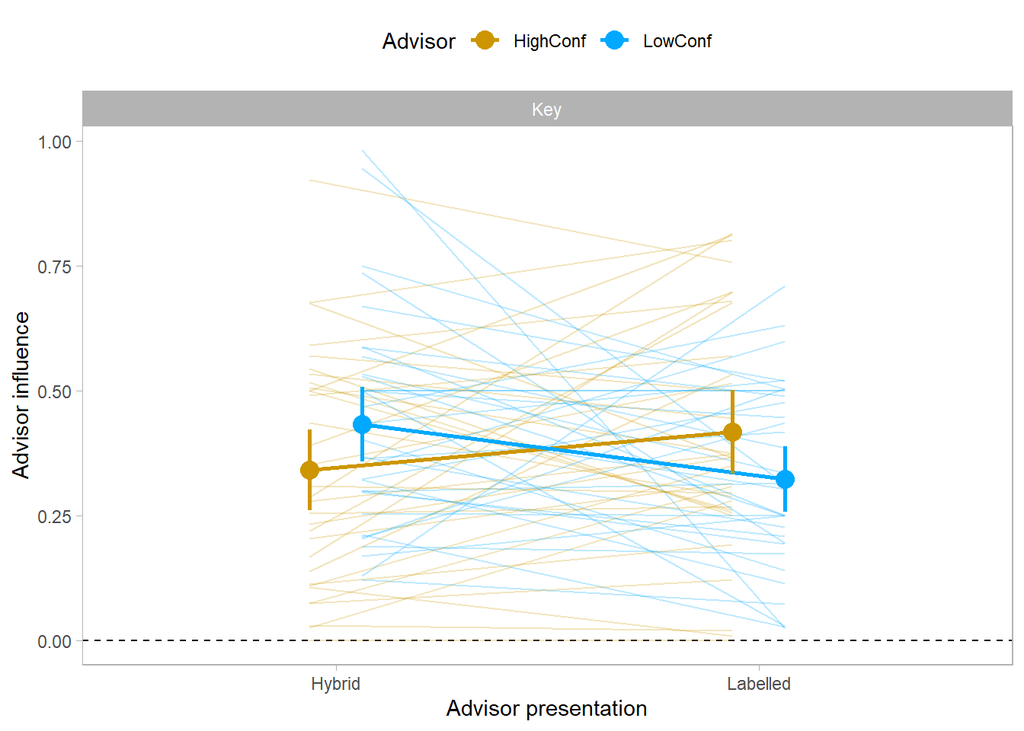

### Summary

The ANOVA revealed an interaction between advisor identity and advisor presentation for both measures of influence (influence and Advice Weight). The low confidence advisor is more highly weighted when presenting advice with confidence in the overlap zone when that advisor is presented as a hybrid. The opposite is true for the high confidence advisor, which is more highly weighted when presented as itself. We would expect the opposite pattern to be the case: when advice is presented as coming from the low confidence advisor it should be recognised as relatively high confidence, whereas when it is presented as coming from the hybrid it is of indeterminate confidence. Likewise, advice presented as coming from the high confidence advisor should be recognised as having relatively low confidence.

## Comparing influence by favourite advisor

Hybrid vs labelled for favourite advisor.

```
## *t*(34) = -0.49, *p*  = .630, *d* = 0.09, BF = 0.20; *M*|Labelled = 25.54 [17.39, 33.68], *M*|Hybrid = 27.94 [17.67, 38.20]
```

## As above but comparing favourite to least favourite advisor

```
## *t*(34) = 0.14, *p*  = .893, *d* = 0.03, BF = 0.18; *M*|Favourite = 25.54 [17.39, 33.68], *M*|Non-favourite = 24.96 [18.41, 31.50]
```

## Time taken vs accuracy

There is considerable variation in the time participants take to produce their initial estimates - to what extent is this variation predictive of accuracy?

```
## [1] "Initial decisions"
```

```
## Bayes factor analysis
## --------------
## [1] Alt., r=0.333 : 0.7298157 ±0%
##
## Against denominator:
##   Null, rho = 0
## ---
## Bayes factor type: BFcorrelation, Jeffreys-beta*
```

```
## [1] "Final decisions"
```

```
## Bayes factor analysis
## --------------
## [1] Alt., r=0.333 : 0.4223325 ±0%
##
## Against denominator:
##   Null, rho = 0
## ---
## Bayes factor type: BFcorrelation, Jeffreys-beta*
```

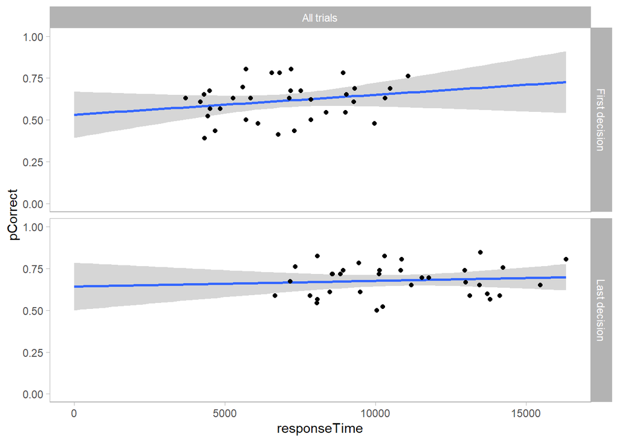

Is the same pattern true within participants as well as between them?

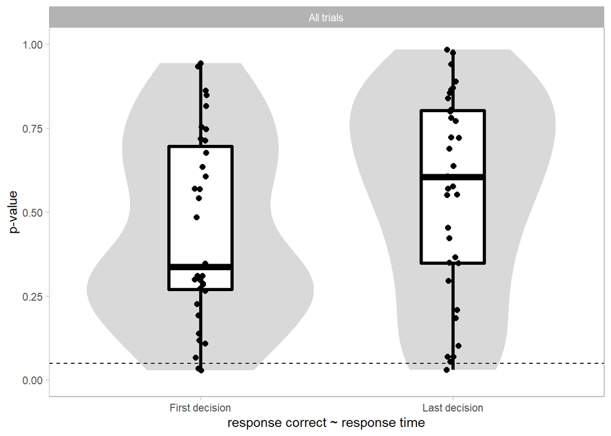

### Summary

There does not seem to be a clear association between the time taken to answer a question and the probability of giving a correct answer for either initial or final responses.

## Why are hybrids as different as labelled advisors?

The hybrids are by definition identical to one another in presentation, with the only exception being that the hybrids have different Foil advice (though the participants don’t know this). They should not, therefore, have differences in how they are treated by the participants, but apparently they kinda do.

### The problem

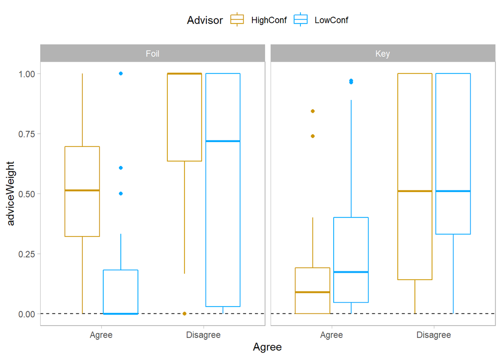

Not so much on the Foil trials, where differences are expected as a function of the advice, but in the key trials, where differences are not expected because advice should be equal.

The statistical extent of the differences:

```
## Bayes factor analysis
## --------------
## [1] Alt., r=0.707 : 0.5517019 ±0%
##
## Against denominator:
##   Null, mu1-mu2 = 0
## ---
## Bayes factor type: BFindepSample, JZS
```

Looks like nothing too untoward is going on, really, but perhaps worth checking how the raw data look, anyway.

### Raw confidence rating stats

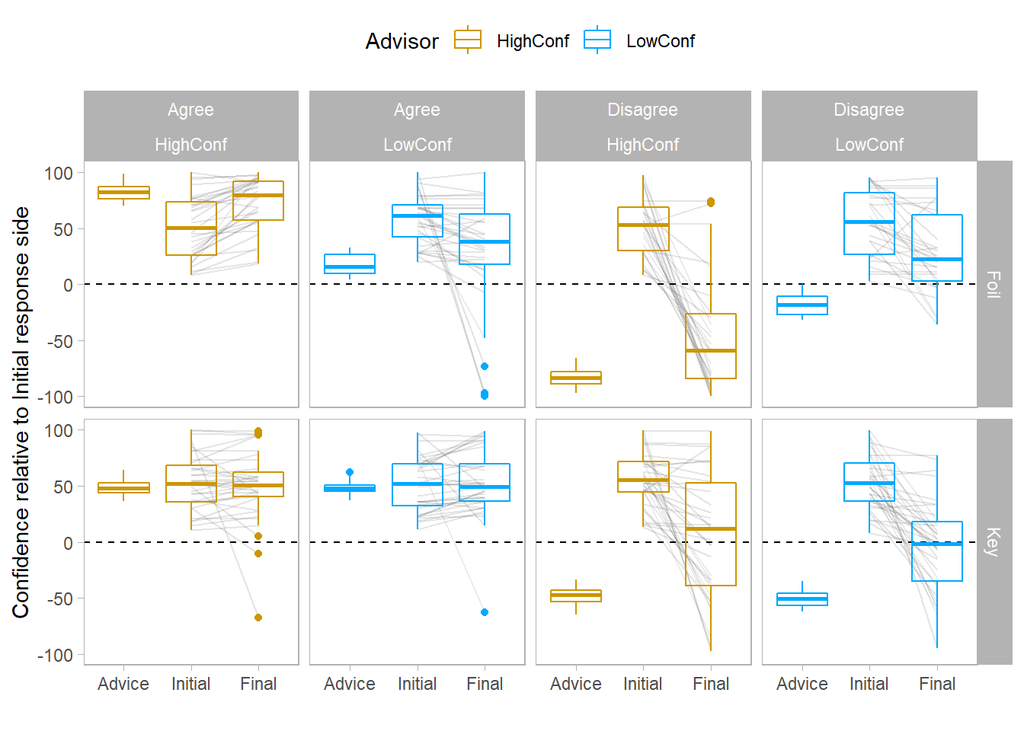

As planned, in the Key trials the advisors’ confidences are identical, while they differ in the Foil trials. The responses to the advisors are quite pronounced, but the patterns look very similar between advisors. The major difference is in the Foil disagreement trials: participants seem to respond to low-confidence disagreement by sticking to their own initial estimate side, while they mostly switch side when given high-confidence disagreement. This all makes sense, given that the Foil trials identify the advisor, and they give a good indication of p(correct) through confidence.

The puzzle is not so clear here in the Key trials: both hybrids appear to be treated very similarly, with only a slight difference in the disagree trials between the two, in which the responses are revised downwards a little more when given by the LowConf hybrid (although this looks a lot like noise). In light of this plot, the differences in the disagreement trials between the hybrids pointed out above look fairly benign.

### Checking Hybrid advisor images

Worth looking at a few of the images participants saw to double-check they’re identical regardless of the advisor behind the scenes.

```
## HighConf HybridLowConf HybridHighConf HybridLowConf HybridHighConf HybridLowConf HybridHighConf HybridLowConf HybridHighConf HybridLowConf HybridHighConf HybridLowConf Hybrid
```

[figure not shown]

These images show that the hybrid picture is calculated appropriately regardless of which underlying advisor is offering the advice. The differences in the data, which are not statistically significant, are likely to be the result of random chance rather than any systematic difference in responding to one underlying advice distribution versus another.

# Conclusions

The participants appeared to perform the basic task as intended. They were slightly more accurate than we have come to expect. Following advice, they appeared to show some metacognitive sensitivity.

The advice presented throughout the experiment appeared as planned. This advice was more influential in disagreement than agreement, and this remained true (though the discrepancy was reduced) when using an alternate measure of advice taking.

Advice taking was not clearly differentiated between advisors or presentations during the key trials, but nor was it especially clear that the advisors and presentations were treated the same.

A puzzle, perhaps a concern, is that the interaction of presentation and advisor in the ANOVA indicates participants do the opposite of what would be predicted by a normative model: being more influenced by the high confidence advisor’s advice than the hybrid’s advice when the advice shown is in the overlap zone.

Further investigation with additional data collection illustrated that the absence of findings was probably reflective of the underlying truth: we were unable to get the basic manipulation to work. During training, we attempted to teach participants that the advisors were equally accurate, and only differed in their expressed confidence. We did this through direct experience, as well as by showing a scorecard to the participants with a visual depiction of the pattern. Furthermore, we showed participants the scorecards of the two advisors and allowed them to directly compare these (alongside their own). Despite this, participants were still much more influenced by the advice of the high confidence advisor (when labelled) overall, and may have been more influenced by the high confidence advisor’s advice *even in the overlap*. The confidence heuristic thus appears very difficult to overcome, although there is good theoretical justification that it should be possible to do so (e.g. Cecelia Heyes’ paper on training people that fluency is an indicator of unfamiliarity). Given the timeline of the thesis, the empirical question of whether this heuristic can be overcome through training will have to remain uninvestigated here.

The confidence heuristic itself is probably a cultural construction, and there is evidence that, broadly speaking, consensus exists about the mapping of objective probability onto metacognitive terms (Dan Bang, Cecelia Heyes, et al.’s paper on Cultural Evolution of Metacognition has a reference). Participants may have strong expectations that their advisors will use the confidence scale in an appropriate way if they (reasonably enough) view the proportion of the bar filled as an estimate of objective probability of being correct. We failed to overcome this expectation through training. It is possible that participants view the low confidence advisor as being metacognitively incompetent rather than cautious. A paradigm where the participant’s success is tied to sensitivity to the advisor’s confidence (as Maja is developing) may help train participants to adjust for confidence differences more effectively.

Overall, we have tried in a few experiments to produce an environment where participants could demonstrate sensitivity to *knowledge about* advisors’ communication of confidence, and have not been successful in these attempts. It remains theoretically possible, and the evolutionary models which prompted the study offer some indication that it may be the case, but we cannot offer behavioural evidence. It may be that the effect is too subtle in contrast with the confidence heuristic; it may be that discounting in response to unknown confidence mapping is flexible only on a longer timescale than that studied here (evolutionary, cultural evolutionary, lifespan, or relationship); or it may be that no effects exist to demonstrate, or that the effects are too slight to detect.

# Credits

## Acknowledgements

Thanks as always to Nick Yeung and the other folks at the [ACC Lab](https://www.psy.ox.ac.uk/research/attention-cognitive-control-lab).

## R Packages

| Package | Citations |
| --- | --- |
| base | R Core Team (2018). R: A language and environment for statistical computing. R Foundation for Statistical Computing, Vienna, Austria. URL https://www.R-project.org/. |
| htmltools | RStudio and Inc. (2019). htmltools: Tools for HTML. R package version 0.4.0. https://CRAN.R-project.org/package=htmltools |
| beepr | Rasmus Bååth (2018). beepr: Easily Play Notification Sounds on any Platform. R package version 1.3. https://CRAN.R-project.org/package=beepr |
| curl | Jeroen Ooms (2019). curl: A Modern and Flexible Web Client for R. R package version 4.0. https://CRAN.R-project.org/package=curl |
| testthat | Hadley Wickham. testthat: Get Started with Testing. The R Journal, vol. 3, no. 1, pp. 5–10, 2011 |
| Hmisc | Frank E Harrell Jr, with contributions from Charles Dupont and many others. (2019). Hmisc: Harrell Miscellaneous. R package version 4.2-0. https://CRAN.R-project.org/package=Hmisc |
| Formula | Achim Zeileis, Yves Croissant (2010). Extended Model Formulas in R: Multiple Parts and Multiple Responses. Journal of Statistical Software 34(1), 1-13. doi:10.18637/jss.v034.i01 |
| survival | <br/><br/> |
| lattice | Sarkar, Deepayan (2008) Lattice: Multivariate Data Visualization with R. Springer, New York. ISBN 978-0-387-75968-5 |
| ez | Michael A. Lawrence (2016). ez: Easy Analysis and Visualization of Factorial Experiments. R package version 4.4-0. https://CRAN.R-project.org/package=ez |
| knitr | Yihui Xie (2019). knitr: A General-Purpose Package for Dynamic Report Generation in R. R package version 1.24.<br/><br/>Yihui Xie (2015) Dynamic Documents with R and knitr. 2nd edition. Chapman and Ha… |
| prettyMD | Matt Jaquiery (2020). prettyMD: Format Test Outputs with Markdown. R package version 0.1.3. |
| BayesFactor | Richard D. Morey and Jeffrey N. Rouder (2018). BayesFactor: Computation of Bayes Factors for Common Designs. R package version 0.9.12-4.2. https://CRAN.R-project.org/package=BayesFactor |
| Matrix | Douglas Bates and Martin Maechler (2019). Matrix: Sparse and Dense Matrix Classes and Methods. R package version 1.2-17. https://CRAN.R-project.org/package=Matrix |
| coda | Martyn Plummer, Nicky Best, Kate Cowles and Karen Vines (2006). CODA: Convergence Diagnosis and Output Analysis for MCMC, R News, vol 6, 7-11 |
| broom | David Robinson and Alex Hayes (2019). broom: Convert Statistical Analysis Objects into Tidy Tibbles. R package version 0.5.2. https://CRAN.R-project.org/package=broom |
| scales | Hadley Wickham (2018). scales: Scale Functions for Visualization. R package version 1.0.0. https://CRAN.R-project.org/package=scales |
| forcats | Hadley Wickham (2019). forcats: Tools for Working with Categorical Variables (Factors). R package version 0.4.0. https://CRAN.R-project.org/package=forcats |
| stringr | Hadley Wickham (2019). stringr: Simple, Consistent Wrappers for Common String Operations. R package version 1.4.0. https://CRAN.R-project.org/package=stringr |
| dplyr | Hadley Wickham, Romain François, Lionel Henry and Kirill Müller (2019). dplyr: A Grammar of Data Manipulation. R package version 0.8.3. https://CRAN.R-project.org/package=dplyr |
| purrr | Lionel Henry and Hadley Wickham (2019). purrr: Functional Programming Tools. R package version 0.3.3. https://CRAN.R-project.org/package=purrr |
| readr | Hadley Wickham, Jim Hester and Romain Francois (2018). readr: Read Rectangular Text Data. R package version 1.3.1. https://CRAN.R-project.org/package=readr |
| tidyr | Hadley Wickham and Lionel Henry (2020). tidyr: Tidy Messy Data. R package version 1.0.2. https://CRAN.R-project.org/package=tidyr |
| tibble | Kirill Müller and Hadley Wickham (2019). tibble: Simple Data Frames. R package version 2.1.3. https://CRAN.R-project.org/package=tibble |
| ggplot2 | H. Wickham. ggplot2: Elegant Graphics for Data Analysis. Springer-Verlag New York, 2016. |
| tidyverse | Hadley Wickham (2017). tidyverse: Easily Install and Load the ‘Tidyverse’. R package version 1.2.1. https://CRAN.R-project.org/package=tidyverse |

## Funding

Matt Jaquiery is funded by a studentship from the [Medical Research Council](https://mrc.ukri.org/) (reference 1943590) and the University of Oxford [Department of Experimental Psychology](https://www.psy.ox.ac.uk/) (reference 17/18_MSD_661552).